# Coursera Course 5 - Reproducible Research: Week 2 - Peer Assessment 1

```r
# loading required libraries
library(dplyr)
```

```r
library(ggplot2)
```

## Loading and preprocessing the data

```r
if (!file.exists("activity.csv")) {
  unzip(zipfile="activity.zip")
}
# read csv file
act_org <- read.csv("activity.csv")
dim(act_org)
```

```
## [1] 17568     3
```

```r
head(act_org)
```

```
##   steps       date interval
## 1    NA 2012-10-01        0
## 2    NA 2012-10-01        5
## 3    NA 2012-10-01       10
## 4    NA 2012-10-01       15
## 5    NA 2012-10-01       20
## 6    NA 2012-10-01       25
```

```r
# omit records with NA
act_clean <- na.omit(act_org)
dim(act_clean)
```

```
## [1] 15264     3
```

## What is mean total number of steps taken per day?

1. Calculate the total number of steps taken per day

```r
# records grouped on date and total of steps calculated
act_date_summ <- act_clean %>% select(date, steps) %>% group_by(date) %>% summarize(tot_steps=sum(steps))
dim(act_date_summ)
```

```
## [1] 53  2
```

```r
summary(act_date_summ)
```

```
##          date      tot_steps
##  2012-10-02: 1   Min.   :   41
##  2012-10-03: 1   1st Qu.: 8841
##  2012-10-04: 1   Median :10765
##  2012-10-05: 1   Mean   :10766
##  2012-10-06: 1   3rd Qu.:13294
##  2012-10-07: 1   Max.   :21194
##  (Other)   :47
```

```r
act_date_summ
```

```
## # A tibble: 53 x 2
##          date tot_steps
##        <fctr>     <int>
##  1 2012-10-02       126
##  2 2012-10-03     11352
##  3 2012-10-04     12116
##  4 2012-10-05     13294
##  5 2012-10-06     15420
##  6 2012-10-07     11015
##  7 2012-10-09     12811
##  8 2012-10-10      9900
##  9 2012-10-11     10304
## 10 2012-10-12     17382
## # ... with 43 more rows
```

2. Make a histogram of the total number of steps taken each day

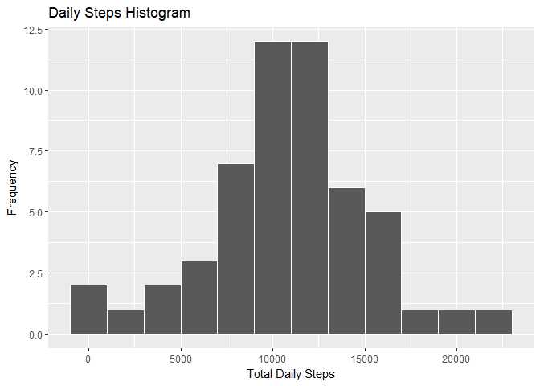

```r
ggplot(act_date_summ, aes(x = tot_steps)) +
       geom_histogram(color = "white", binwidth = 2000) +
  labs(title = "Daily Steps Histogram", x = "Total Daily Steps", y = "Frequency")
```

3. Calculate and report the mean and median of the total number of steps taken per day

```r
mean(act_date_summ$tot_steps)
```

```
## [1] 10766.19
```

```r
median(act_date_summ$tot_steps)
```

```
## [1] 10765
```

## What is the average daily activity pattern?

1. Make a time series plot (i.e. type = “l”) of the 5-minute interval (x-axis) and the average number of steps taken, averaged across all days (y-axis)

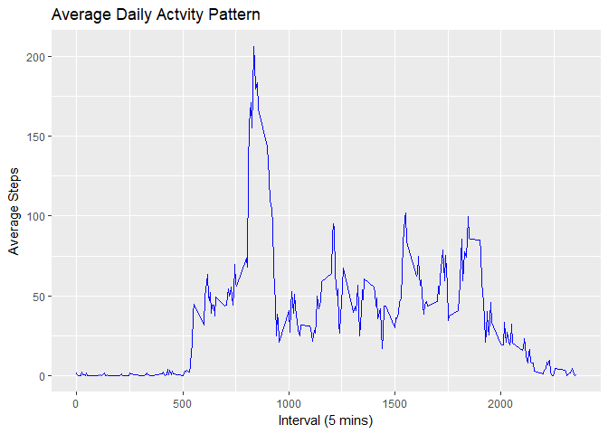

```r
act_interval_mean <- act_clean %>% select(interval, steps) %>% group_by(interval) %>% summarize(avg_steps=mean(steps))
ggplot(act_interval_mean, aes(x = interval, y = avg_steps)) +
       geom_line(color = "blue") +
       labs(title = "Average Daily Actvity Pattern", x = "Interval (5 mins)", y = "Average Steps")
```

2. Which 5-minute interval, on average across all the days in the dataset, contains the maximum number of steps?

```r
act_interval_mean[which.max(act_interval_mean$avg_steps),]
```

```
## # A tibble: 1 x 2
##   interval avg_steps
##      <int>     <dbl>
## 1      835  206.1698
```

## Imputing missing values

1. Calculate and report the total number of missing values in the dataset (i.e. the total number of rows with NAs)

```r
sum(is.na(act_org))
```

```
## [1] 2304
```

2. Strategy for fillin gin all f the missing values in the dataset: Missing values will be replaced with mean for that 5-minute interval

```r
repl_w_mean <- function(x) replace(x, is.na(x), mean(x, na.rm = TRUE))
```

3. Create a new dataset that is equal to the original dataset but with the missing data filled in.

```r
act_new <- act_org%>% group_by(interval) %>% mutate(steps= repl_w_mean(steps))
head(act_new)
```

```
## # A tibble: 6 x 3
## # Groups:   interval [6]
##       steps       date interval
##       <dbl>     <fctr>    <int>
## 1 1.7169811 2012-10-01        0
## 2 0.3396226 2012-10-01        5
## 3 0.1320755 2012-10-01       10
## 4 0.1509434 2012-10-01       15
## 5 0.0754717 2012-10-01       20
## 6 2.0943396 2012-10-01       25
```

```r
# check for any missing value
sum(is.na(act_new))
```

```
## [1] 0
```

4. Make a histogram of the total number of steps taken each day and Calculate and report the mean and median total number of steps taken per day.

```r
# records grouped on date and total of steps calculated
act_new_date_summ <- act_new %>% select(date, steps) %>% group_by(date) %>% summarize(tot_steps=sum(steps))
```

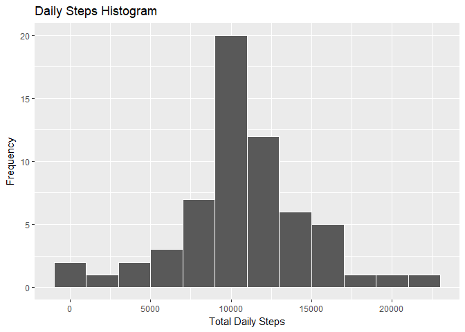

```r
ggplot(act_new_date_summ, aes(x = tot_steps)) +
       geom_histogram(color = "white", binwidth = 2000) +
  labs(title = "Daily Steps Histogram", x = "Total Daily Steps", y = "Frequency")
```

```r
# mean total number of steps taken per day.
mean(act_new_date_summ$tot_steps)
```

```
## [1] 10766.19
```

```r
# median total number of steps taken per day.
median(act_new_date_summ$tot_steps)
```

```
## [1] 10766.19
```

4.1 Do these values differ from the estimates from the first part of the assignment?

The mean value remained same whereas median is shifted upwards by 1.19 steps.

*Earlier Values (after removing missing values)*

```r
mean(act_date_summ$tot_steps)
```

```
## [1] 10766.19
```

```r
median(act_date_summ$tot_steps)
```

```
## [1] 10765
```

*New values (after imputing missing values with mean for that 5-minute interval)*

```r
mean(act_new_date_summ$tot_steps)
```

```
## [1] 10766.19
```

```r
median(act_new_date_summ$tot_steps)
```

```
## [1] 10766.19
```

4.2 What is the impact of imputing missing data on the estimates of the total daily number of steps?

The effect of using mean data per interval as a data imputing method for missing values has pushed the median towards the mean.

## Are there differences in activity patterns between weekdays and weekends?

For this part the weekdays() function may be of some help here. Use the dataset with the filled-in missing values for this part.

1. Create a new factor variable in the dataset with two levels - “weekday” and “weekend” indicating whether a given date is a weekday or weekend day.

```r
# type cast the date column as date so we can use weekdays() function on that column to determine day
act_new$date <- as.Date(act_new$date)
act_new$weekday <- weekdays(act_new$date)
act_new$weekday_weekend <- ifelse(act_new$weekday %in% c("Saturday", "Sunday"), "Weekend", "Weekday" )
head(act_new)
```

```
## # A tibble: 6 x 5
## # Groups:   interval [6]
##       steps       date interval weekday weekday_weekend
##       <dbl>     <date>    <int>   <chr>           <chr>
## 1 1.7169811 2012-10-01        0  Monday         Weekday
## 2 0.3396226 2012-10-01        5  Monday         Weekday
## 3 0.1320755 2012-10-01       10  Monday         Weekday
## 4 0.1509434 2012-10-01       15  Monday         Weekday
## 5 0.0754717 2012-10-01       20  Monday         Weekday
## 6 2.0943396 2012-10-01       25  Monday         Weekday
```

2. Make a panel plot containing a time series plot (i.e. type = “l”) of the 5-minute interval (x-axis) and the average number of steps taken, averaged across all weekday days or weekend days (y-axis).

```r
act_day_summ <- (act_new %>% group_by(interval, weekday_weekend) %>% summarise(mean_steps = mean(steps) ) )
head(act_day_summ)
```

```
## # A tibble: 6 x 3
## # Groups:   interval [3]
##   interval weekday_weekend mean_steps
##      <int>           <chr>      <dbl>
## 1        0         Weekday 2.25115304
## 2        0         Weekend 0.21462264
## 3        5         Weekday 0.44528302
## 4        5         Weekend 0.04245283
## 5       10         Weekday 0.17316562
## 6       10         Weekend 0.01650943
```

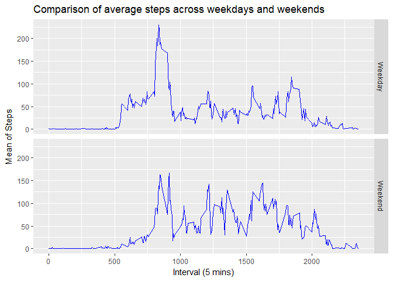

```r
grid_labels <- c(Weekday = "Weekday", Weekend = "Weekend")

ggplot(act_day_summ, aes(x = interval, y = mean_steps)) +
       geom_line(color = "blue") +
       facet_grid(weekday_weekend ~.) +
       labs(title = "Comparison of average steps across weekdays and weekends", x = "Interval (5 mins)", y = "Mean of Steps")
```